# Miles per gallon analysis

Gissur Jónasson

Saturday, May 23, 2015

## Exectuvive summary

This report tries to analyzi and explain the miles per gallon usages of cars based on their designs e.g. horsepower, weight, transmission etc. By analyzing the data it can clearly can be seen that mpg are mostly predicted by weight and horsepower of the cars but if we dig litle deeper it seems that automatic vs manual transmission does play a part although a vague one. By doing hypothesis testing both t test to compare mean between auto vs manual transmission and anova test to compare different predict models for mpg we end by saying that the manual transmission plays a part so by shifting gears yourself you can 2.083710 miles per gallon.

*Note* that the statment is vague as the dataset is not big enough and to get more comfortable with the result I would conduct research on more cars as this dataset does have to much of a heavy automatic transmission cars relative to the manual cars that are lighter.

## Data processing

the data set in this project is a built in data set so we only need to do load it

```r
mtcars <- mtcars
str(mtcars)
```

[output not shown]

The help file for the data set says

| Category | Explanation |
| --- | --- |
| mpg | Miles/(US) gallon |
| cyl | Number of cylinders |
| disp | Displacement (cu.in.) |
| hp | Gross horsepower |
| drat | Rear axle ratio |
| wt | Weight (lb/1000) |
| qsec | 1/4 mile time |
| vs | V/S |
| am | Transmission (0 = automatic, 1 = manual) |
| gear | Number of forward gears |
| carb | Number of carburetors |

so I convert theses field to factors and have that dataset as well for back up when deciding on model.

```r
mtcars_clean <- mtcars
mtcars_clean$am<- as.factor(mtcars_clean$am)
mtcars_clean$vs<- as.factor(mtcars_clean$vs)
mtcars_clean$cyl<- as.factor(mtcars_clean$cyl)
mtcars_clean$gear<- as.factor(mtcars_clean$gear)
mtcars_clean$carb<- as.factor(mtcars_clean$carb)
```

## Exploratory data analysis

First off we start by analyzing the mpg variables with the respect to automatic vs manual transmission see apendix plot 1

There are cleary differences in the mpg values on automatic vs manual. Is this difference significant lets make a t-test

```r
autoData <- mtcars[mtcars$am == 0,]
manualData <- mtcars[mtcars$am == 1,]
t_test <- t.test(autoData$mpg, manualData$mpg)
t_test[[3]]
```

```
## [1] 0.001373638
```

yes it is

Now let look at the mpg based on other variables see apendix plot 2

it looks from these pictures that the data is little skewed as with automatic transmission tend to be heavier and with more horse power in the data set there are though few data points that we can base on.

## Model building

lets now build or models - first off lets check to see what variables will be significant in the linear regression and correlation as well as variance inflation for the whole data set.

```r
#install.packages("Hmisc")
library("Hmisc")
library("car")
correlation<-rcorr(as.matrix(mtcars))
correlation[[1]][,1:6]
fitall <- lm(mpg ~ ., data = mtcars)
#summary(fitall)
fitall_clean <- lm(mpg ~ ., data = mtcars_clean)
#summary(fitall_clean)
vif(fitall)
```

[output not shown]

but for the purpose of this project lets first chek how model based on **am** only comes out

```r
fit1 <- lm(mpg ~ am, data = mtcars_clean)
#summary(fit1)
```

This model does not do that good of a job predciting **mpg** as it only has adjusted r-squared as 33,85% so this model does not fit the data that well but based on that we would conclude that manual transmission on average had 7,245 mpg then the automatic ones.

Lets make a model based on **hp** and **wt** as we had found out they are pretty strong predictors.

```r
fit2 <- update(fit1,mpg ~ wt + hp , data = mtcars)
#summary(fit2)

fit3 <- update(fit1,mpg ~  wt + hp + am, data = mtcars)
#summary(fit3)

anova(fit1,fit2,fit3)
```

```
## Analysis of Variance Table
##
## Model 1: mpg ~ am
## Model 2: mpg ~ wt + hp
## Model 3: mpg ~ wt + hp + am
##   Res.Df    RSS Df Sum of Sq       F    Pr(>F)
## 1     30 720.90
## 2     29 195.05  1    525.85 81.6666 8.567e-10 ***
## 3     28 180.29  1     14.76  2.2918    0.1413
## ---
## Signif. codes:  0 '***' 0.001 '**' 0.01 '*' 0.05 '.' 0.1 ' ' 1
```

We conclude that the mpg is mainly based on **wt** and **hp** but the model gets litle bit better by adding **am** as well so we use that as our final model and for the purpose of this project even thoug the anova test implies that the model with **am** is not significantly different from the one without it by the p value = 0.1413

mpg = 34.002875 - 0.037479 * hp - 2.878575 * wt + 2.083710 * am

so one might say that manual transmission cars on average have 2.083710 more miles then the automatic ones

## Appendix

plot 1:

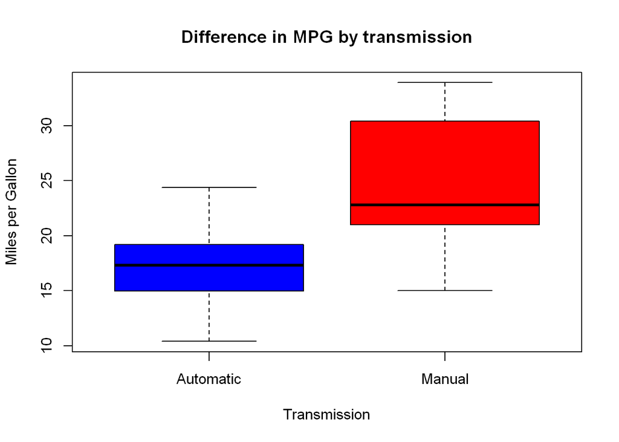

```r
attach(mtcars)
am_mean <-aggregate(mtcars, by=list(am),
                    FUN=mean, na.rm=TRUE)

am_std <-aggregate(mtcars, by=list(am),
                    FUN=sd, na.rm=TRUE)

mtcars_clean$am<-factor(mtcars$am,levels=c(0,1), labels = c("Automatic","Manual"))
boxplot(mpg~am, data = mtcars_clean,
                col = c("blue", "red"),
                main = "Difference in MPG by transmission",
                xlab = "Transmission",
                ylab = "Miles per Gallon"
                )
```

plot 2:

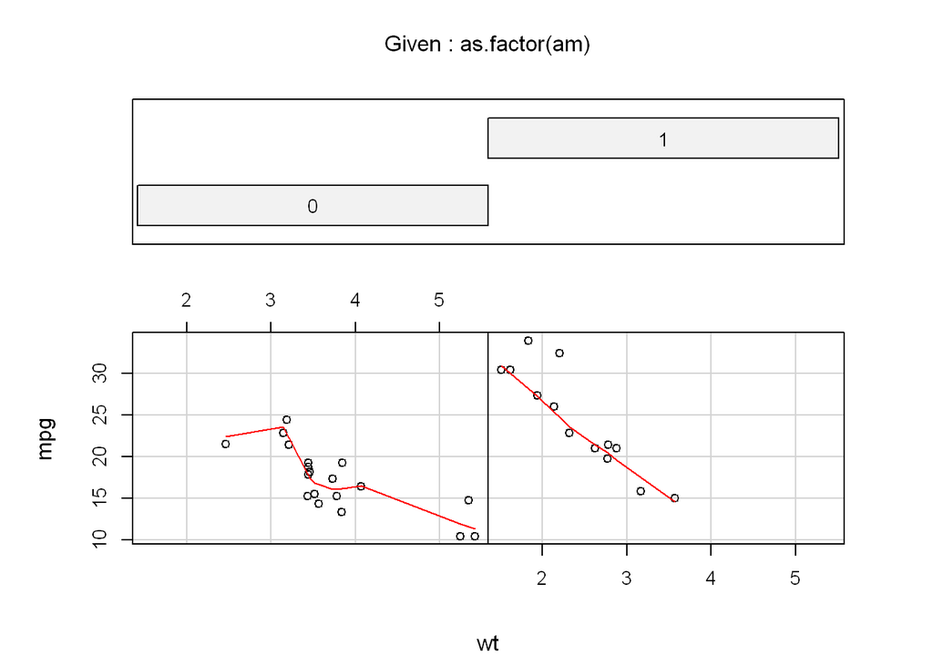

```r
coplot(mpg ~ wt | as.factor(am), data = mtcars,
     panel = panel.smooth, rows = 1)
```

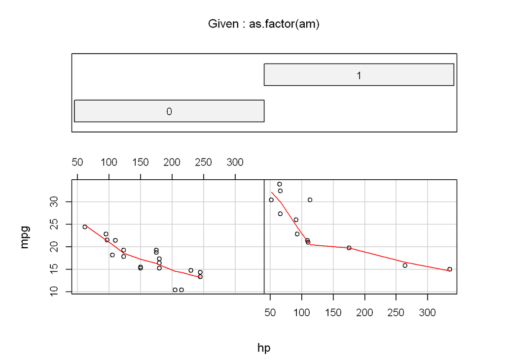

```r
coplot(mpg ~ hp | as.factor(am), data = mtcars,
      panel = panel.smooth, rows = 1)
```

plot 3:

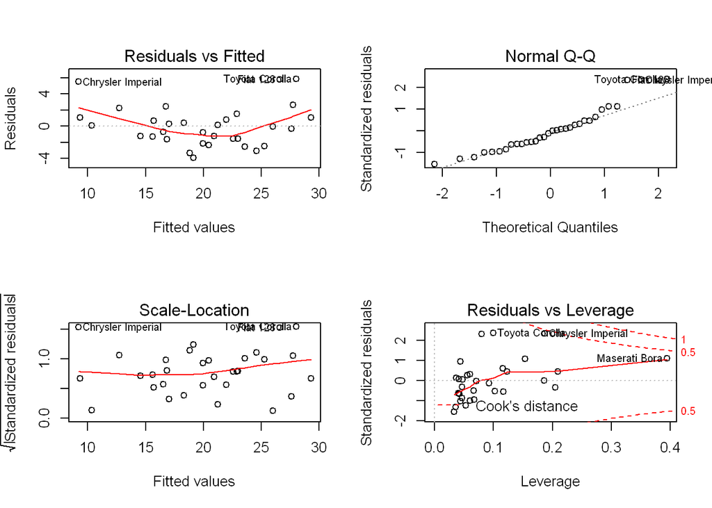

```r
par(mfrow = c(2,2))
plot(fit2)
```